# Homework 2 Report

## Name

Bo Han

### Setup

Read in the data with `read_csv()` and store the data as an R object named `dataset`. Check the data to make sure all of the expected observations and variables are there.

```r
## Load the data and any necessary packages here.
library(tidyverse)
dataset = read_csv("maacs.csv.gz")
```

## Part 1

We will first consider the relationship between FEV1 and age. In general, it is expected that as children get older (and hence, larger in size), their FEV1 values should get higher.

Consider the statement “FEV1 values in children are higher in older children relative to younger children”.

Write a function in R that takes the `dataset` object as an argument and returns `TRUE` if the statement above is true for the dataset and `FALSE` otherwise.

NOTE: In order to write this function, you will need to translate the statement above into something that can be checked with the data. There are many ways in which you can do that translation correctly and you only need to pick one way here.

NOTE: For this part, do not use any plots.

```r
## Write your function here
test_statement = function(dataset){
  # Find the correlation between FEV1 and age and return if it is positive or not
  corr = cor(dataset$fev1, dataset$age, use = "complete.obs")
  return(corr > 0)
}

test_statement(dataset)
```

```
## [1] TRUE
```

## Part 2

Fit a linear regression model with FEV1 as the outcome and age as a predictor.

How much does FEV1 change for a 1-year increase in the child’s age?

```r
## Add your code here
# Fit a linear regression model
model = lm(fev1 ~ age, data = dataset)
coef(model)
```

```
##  (Intercept)          age
## -0.001198833  0.171162271
```

```r
# Store the slope and intercept as objects
slope = as.numeric(coef(model)[2])
intercept = as.numeric(coef(model)[1])
```

Write your data analysis statement interpreting the regression model here: FEV1 increases by 0.171 liters for a 1-year increase in the child’s age.

## Part 3

Develop **three** supporting premises derived from the data that support the statement you wrote in Part 2. These can be plots, other summary statistics, or model results.

NOTE:

- At least one supporting premise should use a plot.
- Do not use the code you write in Part 1 as a supporting premise

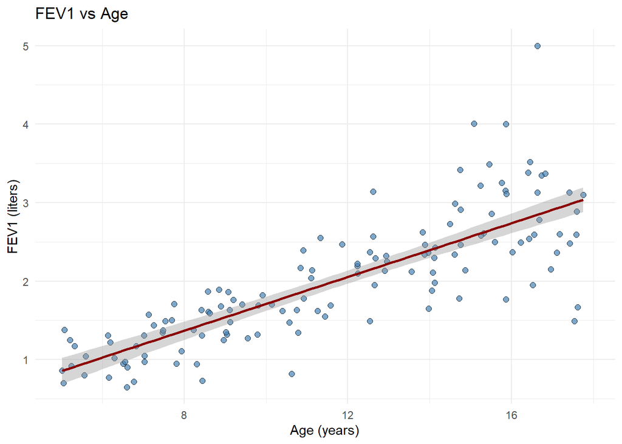

```r
## Add your code here
# Create a scatter plot of FEV1 vs. Age
ggplot(dataset, aes(x = age, y = fev1)) +
  geom_point(shape = 21, size = 2, alpha = 0.7,
             color = "black", fill = "steelblue") +
  geom_smooth(method = "lm", color = "darkred") +
  labs(title = "FEV1 vs Age", x = "Age (years)", y = "FEV1 (liters)") +
  theme_minimal()
```

```r
# Output the slope of the linear regression model
coef(model)[2]
```

```
##       age
## 0.1711623
```

```r
# Group by ages (5, 10], (10, 15], and (15, max(dataset$age)] and output the mean FEV1 values for each age group
dataset %>%
  mutate(ages = cut(age, breaks = seq(min(dataset$age, na.rm = T),
                                      max(dataset$age, na.rm = T), by=5))) %>%
  group_by(ages) %>%
  summarise(mean_fev1 = mean(fev1, na.rm = T))
```

```
## # A tibble: 3 × 2
##   ages    mean_fev1
##   <fct>       <dbl>
## 1 (5,10]       1.28
## 2 (10,15]      2.15
## 3 <NA>         2.87
```

Write the three supporting premise statements here:

1. The scatter plot of FEV1 vs. Age shows a positive linear relationship.
2. The slope from the linear regression model is positive.
3. The mean FEV1 by age group increases along with age.

## Part 4

For each of the supporting premises above, write a function that takes the `dataset` object as an argument and returns `TRUE` if the supporting premise statement above is true for the dataset and `FALSE` otherwise.

For statements involving plots, instead of returning `TRUE` or `FALSE`, you function should do two things:

1. Produce the plot that is used in the statement
2. Produce a hypothetical version of the plot in the event that the statement is true. This can be done using simulated data or by simply hand drawing a plot.

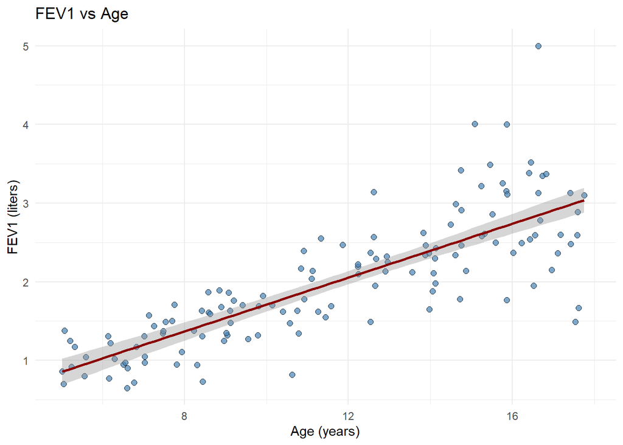

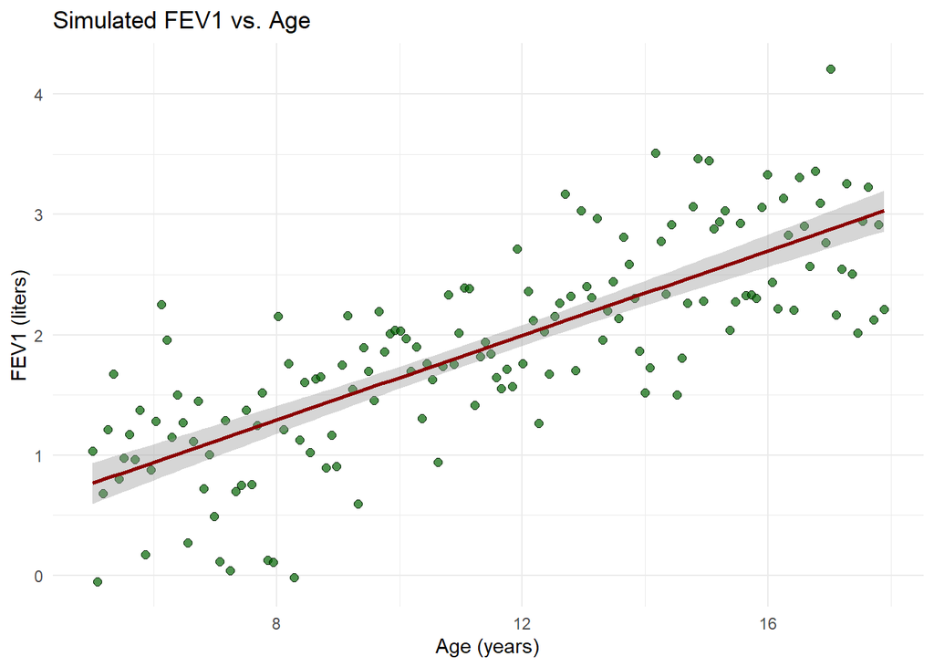

```r
## Function for supporting premise statement 1
prem1 = function(dataset){
  # Create the plot used in the statement
  statement_plot = ggplot(dataset, aes(x = age, y = fev1)) +
  geom_point(shape = 21, size = 2, alpha = 0.7,
             color = "black", fill = "steelblue") +
  geom_smooth(method = "lm", color = "darkred") +
  labs(title = "FEV1 vs Age", x = "Age (years)", y = "FEV1 (liters)") +
  theme_minimal()

  print(statement_plot)

  # Create simulated data of the dataset, creating 150 data points ranging from the
  # minimum and maximum of the original dataset
  set.seed(9-19-2025)
  sim_data = data.frame(age = seq(min(dataset$age, na.rm=T),
                                  max(dataset$age, na.rm=T), length.out = 150))
  # Use the slope and intercept from the linear regression model, plus some noise
  sim_data$fev1 = slope*sim_data$age + intercept + rnorm(150, 0, 0.5)
  # Create a scatter plot now with the simulated data
  sim_plot = ggplot(sim_data, aes(x = age, y = fev1)) +
    geom_point(shape = 21, size = 2, alpha = 0.7,
               color = "black", fill = "darkgreen") +
    geom_smooth(method = "lm", color = "darkred") +
    labs(title = "Simulated FEV1 vs. Age", x = "Age (years)", y = "FEV1 (liters)") +
    theme_minimal()

  print(sim_plot)
}

prem1(dataset)
```

```r
## Function for supporting premise statement 2
prem2 = function(dataset){
  # Return TRUE or FALSE depending if the slope of the linear regression model is
  # positive or not
  model = lm(fev1 ~ age, data = dataset)
  slope = as.numeric(coef(model)[2])
  return(slope > 0)
}

prem2(dataset)
```

```
## [1] TRUE
```

```r
## Function for supporting premise statement 3
prem3 = function(dataset){
  # Group by ages (5, 10], (10, 15], and (15, max(dataset$age)] and output the mean
  # FEV1 values for each age group
  group_mean = dataset %>%
    mutate(ages = cut(age, breaks = seq(min(dataset$age, na.rm = T),
                                        max(dataset$age, na.rm = T), by = 5))) %>%
    group_by(ages) %>%
    summarise(mean_fev1 = mean(fev1, na.rm = T))
  # Return TRUE or FALSE depending on if the differences between each instance of an
  # age group and its previous age group are all positive.
  return(all(diff(group_mean$mean_fev1) > 0))
}

prem3(dataset)
```

```
## [1] TRUE
```

Execute each of your function and show that the produce the expected output.

## Part 5

Describe one alternative to the primary statement “FEV1 values in children are higher in older children relative to younger children”.

Create a fault tree for the alternative outcome describing how the alternative outcome could be realized in the data even if the primary statement were true.

Your fault tree should be created as a separate image and does not need to be created in R. Upload the image of the fault tree to Canvas.